# Multi-level model walk-through

Wizards Points

2023-08-05

## Varying slopes? Varying intercepts?

Our dataset has bench and starter performance by team. Let’s look at the relationship between net rating and win percentage by these groups

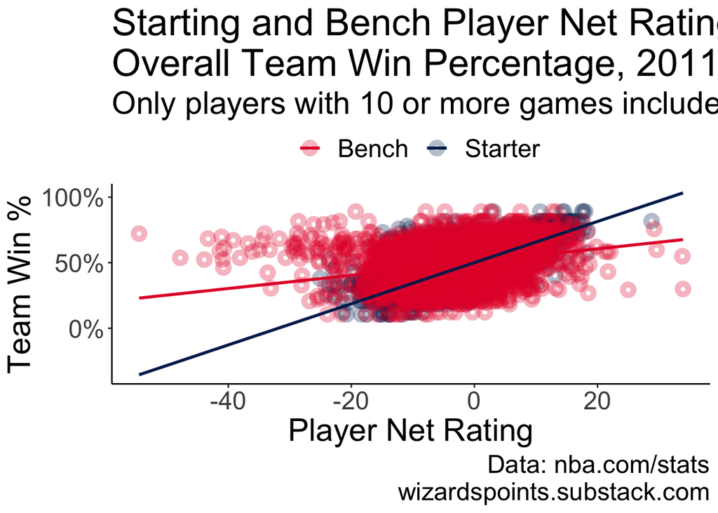

Ok, varying slopes…big time. What about bench performance only by team?

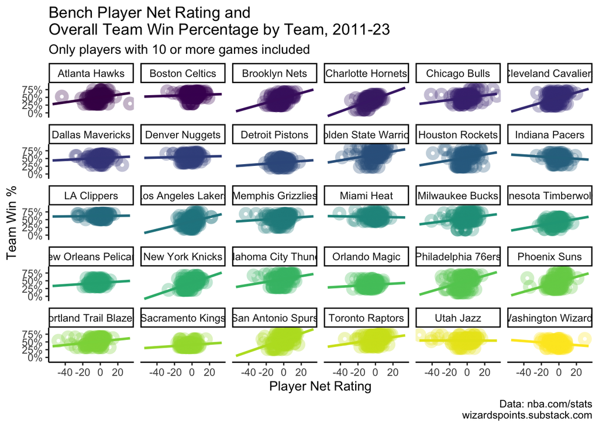

If we simply include a “starter” predictor in our model, we’re estimating different intercepts for starters and bench net ratings–and we know the starter intercept is higher. If we want to know how starter status affects the slope of win percentage, that’s a different specification, one with interactions. The interaction model essentially asks whether or not there is there a difference in the effect of net rating on win percentage for starters and bench players? If we don’t include the interaction we assume that the slope between net rating and win percentage is the same for both starters and bench players.

We could estimate a two-stage regression to estimate the variation by starter status and then by team, or combine these into a multi-level model.

| Level | Equation |
| --- | --- |
| Level 1 | $winpercentage_{ij} = \beta_{0j} + \beta_{1j}netrating_{ij} + \beta_{2ij}minutes_{ij} + E_{ij}$ |
| Level 2 | $\beta_{0j} = \gamma_{00} + \gamma_{10}starter_j + U_{0j}$ |
|  | $\beta_{1j} = \gamma_{10} + \gamma_{11}starter_j + U_{1j}$ |
| Combined | $winpercentage_{ij} = \gamma_{00} + \gamma_{01}netrating_{j} + \gamma_{10}minutes_{ij} + \gamma_{20}starter_{ij} + \gamma_{11}minutes_{ij}*starter_j + U_{0j} + U_{1j}starter_{j} + R_{ij}$ |

With this model, we will be estimating seven different model parameters — 5 fixed effects, 2 random effects:

1. $\gamma_{00}$: the fixed effect for the intercept, controlling for `net rating` , `minutes` and `starter`;
2. $\gamma_{01}$: the fixed effect for the slope of `net rating`, controlling for `starter` and `minutes`;
3. $\gamma_{10}$: the fixed effect for the slope of `minutes`, controlling for `starter` and `minutes`;
4. $\gamma_{20}$: the fixed effect for the slope of `starter`, controlling for `net rating` and `minutes`;
5. $\gamma_{11}$: the fixed effect for the cross-level interaction of`minutes` with `starter`, controlling for `net rating`;
6. $\tau_{01}$: a random effect capturing how a team’s mean win percentage varies around the overall mean win percentage, controlling for `net rating`, `minutes` and `starter`;
7. $\sigma^2$: a random effect capturing the variance of players around their covariance with team win percentage, controlling for `net rating`, `minutes` and `starter`.

A cross-level interaction is interpreted like an interaction in OLS: the effect of starting status on the effect of net rating on win percentage.

```r
# let's create a new data frame just for our variables of interest and rescale them

df_mod <- df %>%
  dplyr::select(team_w_pct, min, net_rating, starter_char, season, team_name, player_name, bench) %>%
  # rescale
  mutate_at(.vars = c(1:3), .funs = arm::rescale) %>%
  arrange(season, player_name)

mlm_1 <- lmer(team_w_pct ~  net_rating + min + bench + min:starter_char + (1|team_name), data = df_mod)

broom.mixed::tidy(mlm_1, conf.int = TRUE)
```

```
## # A tibble: 7 × 8
##   effect   group     term        estimate std.error statistic conf.low conf.high
##   <chr>    <chr>     <chr>          <dbl>     <dbl>     <dbl>    <dbl>     <dbl>
## 1 fixed    <NA>      (Intercept)  -0.0361    0.0386    -0.935  -0.112     0.0396
## 2 fixed    <NA>      net_rating    0.358     0.0104    34.3     0.337     0.378
## 3 fixed    <NA>      min          -0.0663    0.0219    -3.03   -0.109    -0.0234
## 4 fixed    <NA>      bench         0.0454    0.0115     3.94    0.0228    0.0680
## 5 fixed    <NA>      min:starte…   0.107     0.0252     4.26    0.0579    0.156
## 6 ran_pars team_name sd__(Inter…   0.207    NA         NA      NA        NA
## 7 ran_pars Residual  sd__Observ…   0.402    NA         NA      NA        NA
```

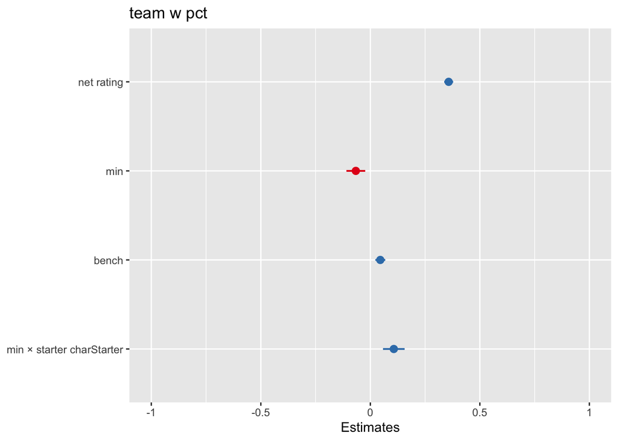

```r
plot_model(mlm_1)
```

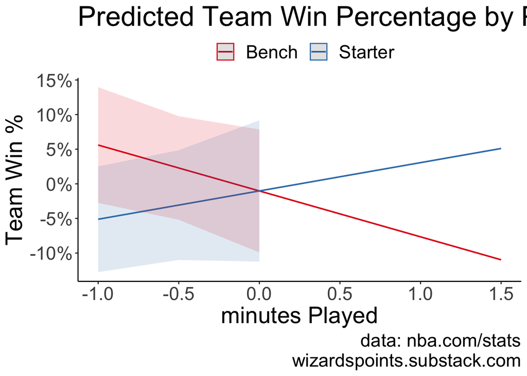

```r
plot_model(mlm_1, type = "int") + theme_classic() +
  labs(x = "minutes Played"
       , y = "Team Win %"
       , title = "Predicted Team Win Percentage by Player Status"
       , caption = "data: nba.com/stats\nwizardspoints.substack.com"
  ) +
  scale_x_continuous(labels = scales::comma_format()) +
  scale_y_continuous(labels = scales::percent_format()) +
  theme(legend.position = "top"
        , legend.title = element_blank()
        , text = element_text(size = 22))
```

Let’s look at the specific team intercepts just for the bench. This will essentially give us a ranking of the interaction.

We can see that for roughly half the league, their benches aren’t doing much for them after we account for variation in net rating by team.

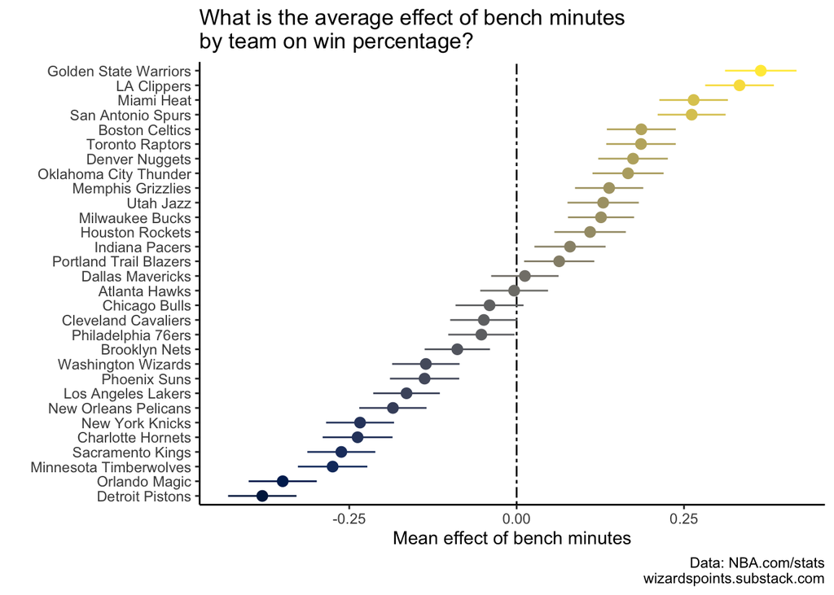

```r
ranef_results <- broom.mixed::tidy(mlm_1, effects = "ran_vals", conf.int = TRUE)

ranef_results %>%
  arrange(desc(estimate)) %>%
  ggplot(aes(x = estimate, y = reorder(level, estimate), xmin = conf.low, xmax = conf.high)) +
  geom_vline(xintercept = 0, linetype = 6) +
  geom_pointrange(aes(col = estimate)) +
  viridis::scale_color_viridis(option = "E") +
  theme_classic() +
  theme(legend.position = "NA") +
  labs(x = "Mean effect of bench minutes", y = "", title = "What is the average effect of bench minutes\nby team on win percentage?", caption = "Data: NBA.com/stats\nwizardspoints.substack.com")
```

# Bring in the original DAG

In our original design, the data are collapsed by starter-bench levels across teams. This still works within a multi-level framework, but likely increases some of the variance of our measures. We should get roughly the same results, but maybe with a little more noise since we are not working at a player-unit level but at a player-status unit level.

```r
df_collapsed <- df %>%
  # drop our character variables
  dplyr::select(team_name, season, bench, net_rating, team_w_pct, min) %>%
  # collapse by team, season, and starter
  group_by(team_name, season, bench) %>%
  summarize(net_rating = mean(net_rating, na.rm=T)
            , team_w_pct = mean(team_w_pct, na.rm=T)
            , min = sum(min, na.rm=T)
            ) %>%
  ungroup()  %>%
  mutate_at(.vars = c("net_rating", "min", "team_w_pct"), .funs = arm::rescale)


mlm_2 <- lmer(team_w_pct~ net_rating + min + bench*min +(1 |team_name), data = df_collapsed)
```

Our model specification is the same for this model, the data are what have changed.

```r
broom.mixed::tidy(mlm_2, conf.int = TRUE)
```

```
## # A tibble: 7 × 8
##   effect   group     term        estimate std.error statistic conf.low conf.high
##   <chr>    <chr>     <chr>          <dbl>     <dbl>     <dbl>    <dbl>     <dbl>
## 1 fixed    <NA>      (Intercept)   -0.138    0.0364     -3.79  -0.209    -0.0666
## 2 fixed    <NA>      net_rating     0.689    0.0268     25.7    0.636     0.741
## 3 fixed    <NA>      min            0.157    0.0609      2.58   0.0377    0.276
## 4 fixed    <NA>      bench          0.213    0.0532      4.00   0.108     0.317
## 5 fixed    <NA>      min:bench     -0.145    0.110      -1.31  -0.361     0.0712
## 6 ran_pars team_name sd__(Inter…    0.105   NA          NA     NA        NA
## 7 ran_pars Residual  sd__Observ…    0.317   NA          NA     NA        NA
```

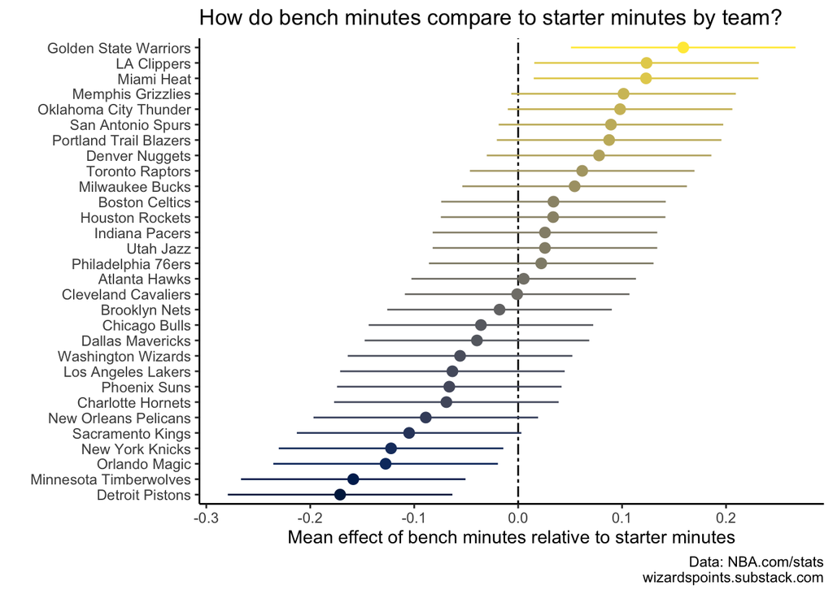

Let’s look at the interaction effect.

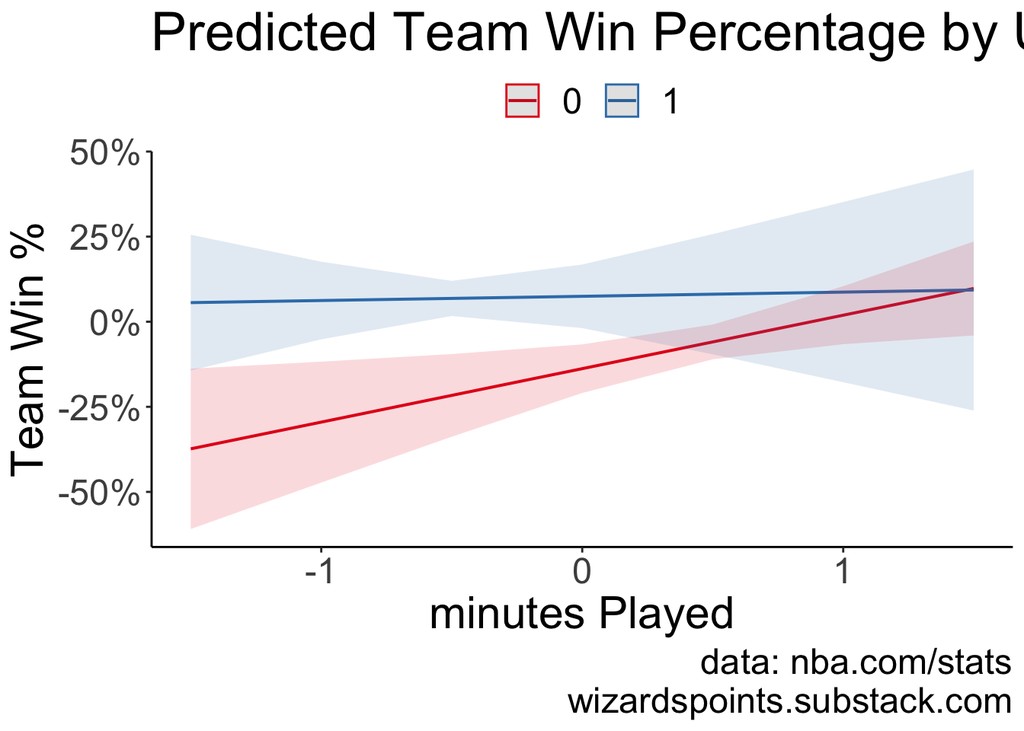

```r
plot_model(mlm_2, type = "int") + theme_classic() +
  labs(x = "minutes Played"
       , y = "Team Win %"
       , title = "Predicted Team Win Percentage by Unit Status"
       , caption = "data: nba.com/stats\nwizardspoints.substack.com"
  ) +
  scale_x_continuous(labels = scales::comma_format()) +
  scale_y_continuous(labels = scales::percent_format()) +
  theme(legend.position = "top"
        , legend.title = element_blank()
        , text = element_text(size = 22))
```

## Getting back to our initial DAG model

We want to run a slightly different model on wider data where instead of an interaction term, we use the actual value for bench minutes, controlling for starter and bench net ratings, with random effects by team.

For context, let’s just look at the relationship between bench minutes and win percentage.

```r
df_wide <- df %>%
  # drop our character variables
  dplyr::select(team_name, season, starter_char, net_rating, team_w_pct) %>%
  # collapse by team, season, and starter
  group_by(team_name, season, starter_char) %>%
  summarize(net_rating = mean(net_rating, na.rm=T)
            , team_w_pct = mean(team_w_pct, na.rm=T)
            ) %>%
  ungroup() %>%
  mutate_at(.vars = c("net_rating",  "team_w_pct"), .funs = arm::rescale) %>%
  pivot_wider(names_from = starter_char, values_from = net_rating) %>%
  left_join(
    df %>%
      # drop our character variables
      dplyr::select(team_name, season, starter, net_rating, min, team_w_pct) %>%
      group_by(team_name, season, starter) %>%
      summarize(total_bench_minutes = sum(min, na.rm=T)
                ) %>%
      filter(starter == 0) %>%
      dplyr::select(-starter) %>%
      ungroup() %>%
      mutate(total_bench_minutes = arm::rescale(total_bench_minutes))
  )
```

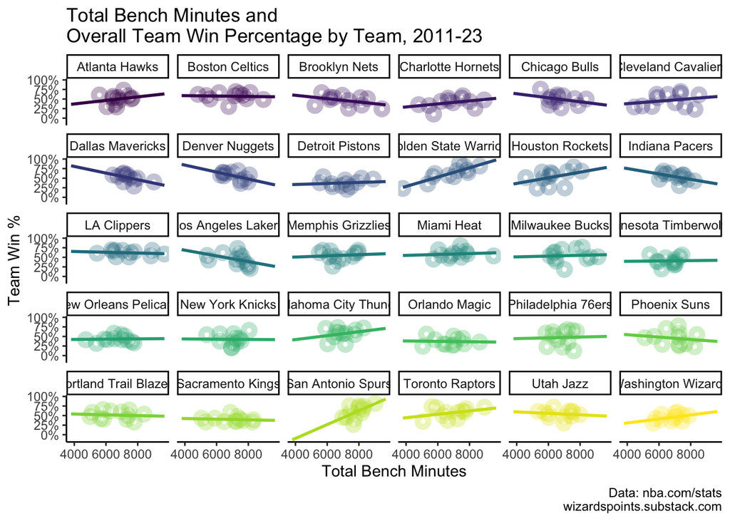

```r
df %>%
  # drop our character variables
  dplyr::select(team_name, season, starter_char, net_rating, team_w_pct) %>%
  # collapse by team, season, and starter
  group_by(team_name, season, starter_char) %>%
  summarize(net_rating = mean(net_rating, na.rm=T)
            , team_w_pct = mean(team_w_pct, na.rm=T)
            ) %>%
  ungroup() %>%
  pivot_wider(names_from = starter_char, values_from = net_rating) %>%
  left_join(
    df %>%
      # drop our character variables
      dplyr::select(team_name, season, starter, net_rating, min, team_w_pct) %>%
      group_by(team_name, season, starter) %>%
      summarize(total_bench_minutes = sum(min, na.rm=T)
                ) %>%
      filter(starter == 0) %>%
      dplyr::select(-starter) ) %>%
      ungroup() %>%
ggplot(aes(x = total_bench_minutes, y = team_w_pct, col = team_name)) +
  geom_point(shape = 21, stroke = 3, alpha = 0.3) +
  geom_smooth(mapping = aes(group = team_name), method = "lm", se = FALSE, fullrange = TRUE) +
  scale_y_continuous(labels = scales::percent_format()) +
  theme_classic() +
  theme(legend.position = "NA"
        , legend.title = element_blank()
        ) +
  labs(x = "Total Bench Minutes", y = "Team Win %"
       , title = "Total Bench Minutes and\nOverall Team Win Percentage by Team, 2011-23"
       , caption = "Data: nba.com/stats\nwizardspoints.substack.com"
  ) +
  viridis::scale_color_viridis(discrete = T) +
  facet_wrap(~team_name)
```

In a model context, this takes the following form:
$$\begin{aligned}
\operatorname{team\_w\_pct}_{i} &\sim N \left(\mu, \sigma^2
\right) \\
\mu &=\alpha_{j[i]} + \beta_{1}(\operatorname{Bench}) +
\beta_{2}(\operatorname{Starter}) +
\beta_{3}(\operatorname{total\_bench\_minutes}) \\
\alpha_{j} &\sim N \left(\mu_{\alpha_{j}},
\sigma^2_{\alpha_{j}} \right)
\text{, for team_name j = 1,} \dots \text{,J}
\end{aligned}$$

```r
mlm_3 <- lmer(team_w_pct~ Bench + Starter + total_bench_minutes + (1|team_name), data = df_wide)


broom.mixed::tidy(mlm_3, conf.int = TRUE)
```

```
## # A tibble: 6 × 8
##   effect   group     term        estimate std.error statistic conf.low conf.high
##   <chr>    <chr>     <chr>          <dbl>     <dbl>     <dbl>    <dbl>     <dbl>
## 1 fixed    <NA>      (Intercept)  -0.0512    0.0123     -4.15 -0.0754    -0.0270
## 2 fixed    <NA>      Bench         0.232     0.0262      8.85  0.181      0.283
## 3 fixed    <NA>      Starter       0.741     0.0186     39.8   0.705      0.778
## 4 fixed    <NA>      total_benc…   0.0313    0.0190      1.64 -0.00602    0.0686
## 5 ran_pars team_name sd__(Inter…   0.0397   NA          NA    NA         NA
## 6 ran_pars Residual  sd__Observ…   0.175    NA          NA    NA         NA
```

Ok, it looks like our overall mean effect, not split out by team is lower. Let’s look at the intercepts, i.e., the overall team level effects. It’s important to note that we have left the realm of separability; we’re not comparing bench minutes to starter minutes, but estimating the effect of bench minutes after accounting for bench and starter performance, as well as team-level variation.

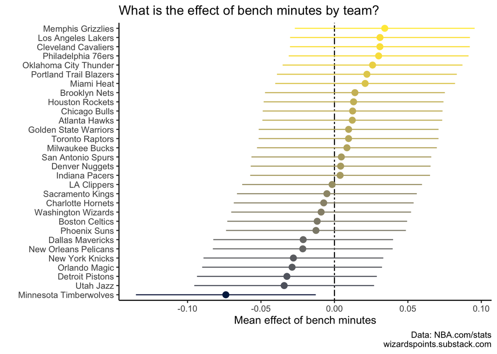

```r
ranef_results3 <- broom.mixed::tidy(mlm_3, effects = "ran_vals", conf.int = TRUE)

ranef_results3 %>%
  arrange(desc(estimate)) %>%
  ggplot(aes(x = estimate, y = reorder(level, estimate), xmin = conf.low, xmax = conf.high)) +
  geom_vline(xintercept = 0, linetype = 6) +
  geom_pointrange(aes(col = estimate)) +
  viridis::scale_color_viridis(option = "E") +
  theme_classic() +
  theme(legend.position = "NA") +
  labs(x = "Mean effect of bench minutes", y = "", title = "What is the effect of bench minutes by team?", caption = "Data: NBA.com/stats\nwizardspoints.substack.com")
```

### Let’s bring in some priors

We know a thing or two about our parameters from watching basketball. Specifically, that starters are good and bench players are typically not as good and bench minutes are not the minutes fans generally go to see (present company excluded).

While Stan defaults to useful, but weakly informative priors, to constrain the uncertainty around the estimates, we can use informative priors based on these assumptions to better estimate the distribution for each parameter. For example, we might think that the bench performance parameter generally has the characteristics $\beta_{1}(\operatorname{Bench}) \in (-5, 3)$, while starter performance is closer to something like $\beta_{2}(\operatorname{Starter}) \in (-1, 6)$, and $\beta_{3}(\operatorname{total bench minutes}) \in (-0.35, -0.01)$ The prior on bench minutes reflects the re-scaled values (i.e., centered and divided by 2 sd’s), so we’re just saying that we thinking bench minutes are mostly negatively correlated with win percentage here.

We can also set a prior on our outcome of win percentage with the following characteristics: $\sim N \left(0.5, 0.1 \right)$

If we had thoughts on the distribution of the error of our model, we could also fit a prior to that, but I don’t really have any thoughts on this, so we’ll just keep the default.

```r
prior_mlm <- normal(location = c(-1, 2.5, -0.18), scale = c(4, 3.5, .17), autoscale = FALSE)


prior_intercept_mlm <- normal(location = 0.5, scale = .1, autoscale = F)


mlm_4 <- stan_lmer(team_w_pct~ Bench + Starter + total_bench_minutes + (1|team_name)
                   , data = df_wide, prior = prior_mlm
                   , prior_intercept = prior_intercept_mlm # on second thought lets drop the intercept prior
                   )


broom.mixed::tidy(mlm_4, conf.int = TRUE)
```

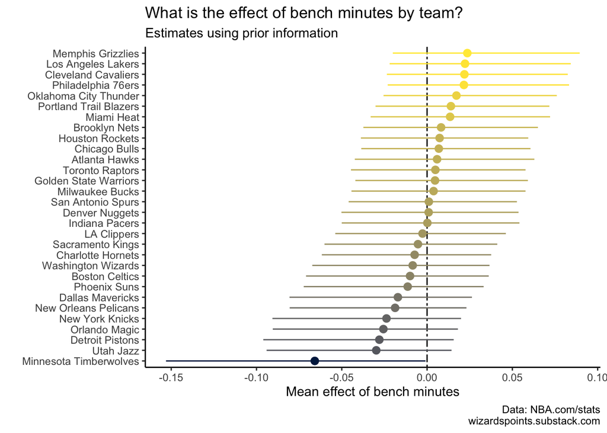

```r
ranef_results4 <- broom.mixed::tidyMCMC(mlm_4, effects = "ran_vals", conf.int = TRUE, conf.level=.9)

ranef_results4 %>%
    filter(grepl("team_name:", term)==T & grepl("Sigma", term)!=T) %>%
    mutate(term = gsub("[_]", " ", substr(term, 25, nchar(term)-1))) %>%
  arrange(desc(estimate)) %>%
  ggplot(aes(x = estimate, y = reorder(term, estimate), xmin = conf.low, xmax = conf.high)) +
  geom_vline(xintercept = 0, linetype = 6) +
  geom_pointrange(aes(col = estimate)) +
  viridis::scale_color_viridis(option = "E") +
  theme_classic() +
  theme(legend.position = "NA") +
  labs(x = "Mean effect of bench minutes", y = "", title = "What is the effect of bench minutes by team?", subtitle = "Estimates using prior information", caption = "Data: NBA.com/stats\nwizardspoints.substack.com")
```

## A linear model

For comparison’s sake, we can see how the multi-level structure compares to a linear model, with the following familiar specification:
$$\operatorname{team\_w\_pct} = \alpha + \beta_{1}(\operatorname{Bench}) +
\beta_{2}(\operatorname{Starter}) +
\beta_{3}(\operatorname{total\_bench\_minutes}) + \epsilon$$

```r
m1 <- lm(team_w_pct ~
           Bench
         + Starter
         +  total_bench_minutes
         , data = df_wide)

broom::tidy(m1, conf.int = TRUE)
```

```
## # A tibble: 4 × 7
##   term                estimate std.error statistic   p.value conf.low conf.high
##   <chr>                  <dbl>     <dbl>     <dbl>     <dbl>    <dbl>     <dbl>
## 1 (Intercept)          -0.0513    0.0102     -5.04 7.45e-  7 -0.0713    -0.0313
## 2 Bench                 0.234     0.0260      9.01 1.31e- 17  0.183      0.285
## 3 Starter               0.744     0.0184     40.5  2.36e-135  0.708      0.780
## 4 total_bench_minutes   0.0315    0.0192      1.64 1.02e-  1 -0.00629    0.0692
```

We can see the multi-level structure at work in the difference overall mean values for bench minutes: lower error, lower magnitude of effect. If we want to re-create the above plot, we can see this difference by team.

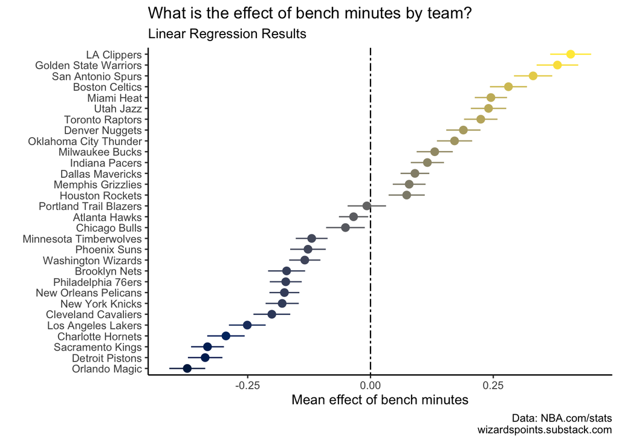

```r
df_wide2 <- df_wide %>% bind_cols(predict(m1, interval = "confidence"))

df_wide2 %>%
  group_by(team_name) %>%
  summarize(fit = mean(fit, na.rm=T)
            , lwr = mean(lwr, na.rm=T)
            , upr = mean(upr, na.rm=T)) %>%
ggplot(aes(x = fit, y = reorder(team_name, fit), xmin = lwr, xmax = upr)) +
  geom_vline(xintercept = 0, linetype = 6) +
  geom_pointrange(aes(col = fit)) +
  viridis::scale_color_viridis(option = "E") +
  theme_classic() +
  theme(legend.position = "NA") +
  labs(x = "Mean effect of bench minutes", y = "", title = "What is the effect of bench minutes by team?", subtitle = "Linear Regression Results", caption = "Data: NBA.com/stats\nwizardspoints.substack.com")
```